# 📘 Notebook 02: Palmer Penguins, Which Species Is This?

### Course: *From Questions to Answers: Classic Datasets, Fully Explored*

**Instructor:** Ioannis Tsioulis

*Dataset 2 · Palmer Archipelago penguins (344 birds, 7 columns)*

> 💡 **This notebook is already run.** Every table and chart below was produced by the code above it, and each result is followed by a comment that explains what it shows. You can read it without running anything. To experiment, choose **Runtime → Run all** in Colab; the whole notebook runs in well under a minute. If you rerun it, numbers from the models may differ slightly in the last decimal, because Colab may have newer library versions.

## 🎯 Learning objectives

By the end of this notebook you will be able to:

- Explore **numeric measurements** with histograms, box plots and scatter plots
- Read a **pair plot** and decide which variables separate groups
- Recognise **Simpson's paradox**: a trend that reverses when the data is split into groups
- Explain why **scaling** matters for distance-based methods such as k-means
- Compare **clusters found without labels** with the true labels
- Find the **smallest set of measurements** that identifies a species

> **Prerequisites:** [Notebook 01: Titanic](https://colab.research.google.com/github/giannis00/giannis00.github.io/blob/main/assets/jupyter/from-questions-to-answers/01_titanic.ipynb), or basic pandas and seaborn.

> 🔭 **Why this notebook matters:** the Titanic was about categories and rates. Most real data, from sensors to medical tests, is **measurements**: lengths, weights, durations. The Palmer Penguins dataset is the modern replacement for the old Iris flowers: small, clean enough to start with, messy enough to be honest, and full of patterns that are easy to see once you know where to look.

## 0. The question

Between 2007 and 2009, Dr Kristen Gorman and the Palmer Station Long Term Ecological Research programme in Antarctica measured penguins of three species on three islands. For each bird we know its species, island, sex, body mass and three measurements of its bill and flipper.

**Our question:** *Can we tell which species a penguin is from its measurements?* More precisely:

1. Which measurements differ between species, and which are almost the same?
2. Would the species be visible in the measurements **even if nobody had labelled them**?
3. What is the **smallest** set of measurements a field researcher would need?

```python
import warnings
warnings.filterwarnings("ignore")

import pandas as pd
import numpy as np
import matplotlib.pyplot as plt
import seaborn as sns

pd.set_option("display.precision", 3)
sns.set_theme(style="whitegrid")
plt.rcParams["figure.dpi"] = 80
```

## 1. Loading the data from a URL

The data is the public copy distributed with the seaborn library.

```python
URL = "https://raw.githubusercontent.com/mwaskom/seaborn-data/master/penguins.csv"
df = pd.read_csv(URL)
print(df.shape)
df.head()
```

```
(344, 7)
```

|  | species | island | bill_length_mm | bill_depth_mm | flipper_length_mm | body_mass_g | sex |
| --- | --- | --- | --- | --- | --- | --- | --- |
| 0 | Adelie | Torgersen | 39.1 | 18.7 | 181.0 | 3750.0 | MALE |
| 1 | Adelie | Torgersen | 39.5 | 17.4 | 186.0 | 3800.0 | FEMALE |
| 2 | Adelie | Torgersen | 40.3 | 18.0 | 195.0 | 3250.0 | FEMALE |
| 3 | Adelie | Torgersen | NaN | NaN | NaN | NaN | NaN |
| 4 | Adelie | Torgersen | 36.7 | 19.3 | 193.0 | 3450.0 | FEMALE |

**What we see.** 344 penguins and 7 columns: two categories (`species`, `island`), four measurements in millimetres and grams, and `sex`. Row 3 is almost completely empty: a bird that was recorded but not measured.

## 2. First look and missing values

```python
df.info()
```

```
<class 'pandas.core.frame.DataFrame'>
RangeIndex: 344 entries, 0 to 343
Data columns (total 7 columns):
 #   Column             Non-Null Count  Dtype
---  ------             --------------  -----
 0   species            344 non-null    object
 1   island             344 non-null    object
 2   bill_length_mm     342 non-null    float64
 3   bill_depth_mm      342 non-null    float64
 4   flipper_length_mm  342 non-null    float64
 5   body_mass_g        342 non-null    float64
 6   sex                333 non-null    object
dtypes: float64(4), object(3)
memory usage: 18.9+ KB
```

```python
df[df.isna().any(axis=1)]
```

|  | species | island | bill_length_mm | bill_depth_mm | flipper_length_mm | body_mass_g | sex |
| --- | --- | --- | --- | --- | --- | --- | --- |
| 3 | Adelie | Torgersen | NaN | NaN | NaN | NaN | NaN |
| 8 | Adelie | Torgersen | 34.1 | 18.1 | 193.0 | 3475.0 | NaN |
| 9 | Adelie | Torgersen | 42.0 | 20.2 | 190.0 | 4250.0 | NaN |
| 10 | Adelie | Torgersen | 37.8 | 17.1 | 186.0 | 3300.0 | NaN |
| 11 | Adelie | Torgersen | 37.8 | 17.3 | 180.0 | 3700.0 | NaN |
| 47 | Adelie | Dream | 37.5 | 18.9 | 179.0 | 2975.0 | NaN |
| 246 | Gentoo | Biscoe | 44.5 | 14.3 | 216.0 | 4100.0 | NaN |
| 286 | Gentoo | Biscoe | 46.2 | 14.4 | 214.0 | 4650.0 | NaN |
| 324 | Gentoo | Biscoe | 47.3 | 13.8 | 216.0 | 4725.0 | NaN |
| 336 | Gentoo | Biscoe | 44.5 | 15.7 | 217.0 | 4875.0 | NaN |
| 339 | Gentoo | Biscoe | NaN | NaN | NaN | NaN | NaN |

**What we see.** Only **11** rows have a gap. Two birds (rows 3 and 339) have no measurements at all, and nine more are missing only `sex`.

**Decision:** we drop the 11 rows. That loses 3% of the data, and filling in a penguin's sex by guessing would be harder to defend than simply working with 333 complete birds. With very little missing, the simple choice is the right one; the Titanic needed more care because a fifth of the ages were missing.

```python
df = df.dropna().reset_index(drop=True)
print(len(df), "complete penguins")
df["species"].value_counts()
```

```
333 complete penguins
```

```
Adelie       146
Gentoo       119
Chinstrap     68
Name: species, dtype: int64
```

**What we see.** 333 complete birds: **146 Adelie**, **119 Gentoo** and **68 Chinstrap**. The classes are not balanced: a model that always answered "Adelie" would be right **43.8%** of the time. That is our baseline.

```python
pd.crosstab(df["species"], df["island"])
```

| island species | Biscoe | Dream | Torgersen |
| --- | --- | --- | --- |
| Adelie | 44 | 55 | 47 |
| Chinstrap | 0 | 68 | 0 |
| Gentoo | 119 | 0 | 0 |

**What we see.** A strong pattern that is **not** about the birds' bodies: Gentoo live only on Biscoe, Chinstrap only on Dream, and Adelie on all three islands. If we used `island` to predict species, a model would look very clever, but it would only have learned where the researchers went. For our question, *measurements*, we keep `island` out of the models.

## 3. One measurement at a time

```python
measures = ["bill_length_mm", "bill_depth_mm", "flipper_length_mm", "body_mass_g"]
df.groupby("species")[measures].mean().round(1)
```

| species | bill_length_mm | bill_depth_mm | flipper_length_mm | body_mass_g |
| --- | --- | --- | --- | --- |
| Adelie | 38.8 | 18.3 | 190.1 | 3706.2 |
| Chinstrap | 48.8 | 18.4 | 195.8 | 3733.1 |
| Gentoo | 47.6 | 15.0 | 217.2 | 5092.4 |

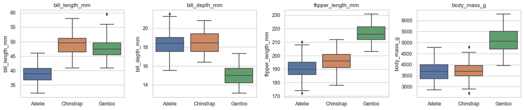

```python
fig, axes = plt.subplots(1, 4, figsize=(16, 3.5))
for ax, col in zip(axes, measures):
    sns.boxplot(data=df, x="species", y=col, ax=ax)
    ax.set_title(col)
    ax.set_xlabel("")
plt.tight_layout()
plt.show()
```

**What we see.** Each measurement separates the species in a **different** way:

- **Flipper length** and **body mass** separate **Gentoo** from the other two: Gentoo are much bigger (mean flipper **217 mm** and mass **5,092 g**, against about 190 mm and 3,700 g), but Adelie and Chinstrap overlap almost completely.
- **Bill length** separates **Adelie** (mean **38.8 mm**) from the other two (about 48 mm).
- **Bill depth** separates **Gentoo** (mean **15.0 mm**, a slim bill) from the other two (about 18.3 mm).

No single measurement separates all three species. But two measurements that fail in **different** places might succeed together. That is the idea behind looking at pairs.

## 4. Pairs of measurements

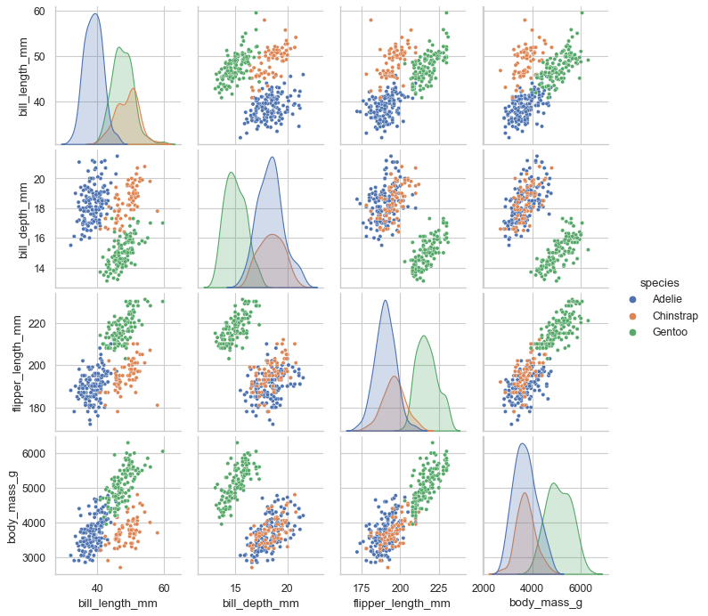

```python
sns.pairplot(df, vars=measures, hue="species", height=2.2, plot_kws={"s": 15})
plt.show()
```

**What we see.** A pair plot draws every pair of measurements as a scatter plot, with the distribution of each measurement on the diagonal. Look for panels where the three colours form **three separate clouds**:

- **Bill length against flipper length** (and against bill depth) shows three clear groups.
- **Flipper length against body mass** shows only two: Gentoo, and everyone else mixed together.

So the answer to "which pair of measurements identifies the species?" is already visible: bill length, combined with either flipper length or bill depth.

### A trap: Simpson's paradox

```python
print("Correlation of bill length and bill depth, all penguins:", round(df["bill_length_mm"].corr(df["bill_depth_mm"]), 2))
for species, group in df.groupby("species"):
    print(f"  within {species:9s}:", round(group["bill_length_mm"].corr(group["bill_depth_mm"]), 2))
```

```
Correlation of bill length and bill depth, all penguins: -0.23
  within Adelie   : 0.39
  within Chinstrap: 0.65
  within Gentoo   : 0.65
```

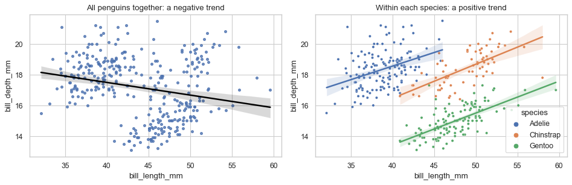

```python
fig, axes = plt.subplots(1, 2, figsize=(12, 4))
sns.regplot(data=df, x="bill_length_mm", y="bill_depth_mm", ax=axes[0], scatter_kws={"s": 12}, line_kws={"color": "black"})
axes[0].set_title("All penguins together: a negative trend")
sns.scatterplot(data=df, x="bill_length_mm", y="bill_depth_mm", hue="species", s=15, ax=axes[1])
for species, group in df.groupby("species"):
    sns.regplot(data=group, x="bill_length_mm", y="bill_depth_mm", scatter=False, ax=axes[1])
axes[1].set_title("Within each species: a positive trend")
plt.tight_layout()
plt.show()
```

**What we see.** Over all penguins, the correlation between bill length and bill depth is **-0.23**: longer bills seem to be shallower. But **within every single species** the correlation is **positive**: **+0.39** for Adelie, **+0.65** for Chinstrap and Gentoo. Within a species, a bigger bird simply has a bigger bill in every direction, as you would expect.

The overall trend is negative only because the species sit in different corners: Gentoo have long **and** shallow bills, Adelie short **and** deep ones. Mixing groups reversed the true relationship. This is **Simpson's paradox**, and it is the reason to **always ask whether your data contains groups** before trusting a correlation. In the Titanic notebook, class hid behind the port; here, species hides behind the bill.

```python
df.groupby(["species", "sex"])["body_mass_g"].mean().unstack().round(0)
```

| sex species | FEMALE | MALE |
| --- | --- | --- |
| Adelie | 3369.0 | 4043.0 |
| Chinstrap | 3527.0 | 3939.0 |
| Gentoo | 4680.0 | 5485.0 |

## 5. Would the species appear without labels?

### Intuition first

Suppose nobody had told us the species. Could an algorithm discover three groups on its own? **k-means** tries to split the points into *k* groups so that each point is close to the centre of its group. It knows nothing about species: we only compare its groups with the true labels afterwards.

But "close" is measured in the original units, and here body mass is in **grams** (values around 4,000) while bills are in **millimetres** (values around 15 to 50). A difference of 500 g would count far more than a difference of 10 mm, although 10 mm in a bill is huge. **Scaling** each measurement to mean 0 and standard deviation 1 gives every measurement an equal voice.

```python
from sklearn.cluster import KMeans
from sklearn.preprocessing import StandardScaler
from sklearn.metrics import adjusted_rand_score

X = df[measures]
raw_groups = KMeans(n_clusters=3, n_init=10, random_state=42).fit_predict(X)
scaled_groups = KMeans(n_clusters=3, n_init=10, random_state=42).fit_predict(StandardScaler().fit_transform(X))

print("Agreement with the true species (adjusted Rand index, 1 = perfect, 0 = chance)")
print("  without scaling:", round(adjusted_rand_score(df["species"], raw_groups), 2))
print("  with scaling:   ", round(adjusted_rand_score(df["species"], scaled_groups), 2))
pd.crosstab(df["species"], scaled_groups, colnames=["cluster (scaled)"])
```

```
Agreement with the true species (adjusted Rand index, 1 = perfect, 0 = chance)
  without scaling: 0.32
  with scaling:    0.8
```

| cluster (scaled) species | 0 | 1 | 2 |
| --- | --- | --- | --- |
| Adelie | 124 | 0 | 22 |
| Chinstrap | 5 | 0 | 63 |
| Gentoo | 0 | 119 | 0 |

**What we see.**

- **Without scaling**, the agreement with the true species is only **0.32**: k-means split the birds mostly by body mass, the measurement with the biggest numbers.
- **With scaling**, the agreement jumps to **0.80**. The table shows that one cluster is exactly the **119 Gentoo**, a second holds **124 of the 146 Adelie**, and a third holds **63 of the 68 Chinstrap** together with 22 Adelie.

So yes: the species are visible in the measurements without any labels, as long as the measurements are put on the same scale. The remaining confusion is between Adelie and Chinstrap, the pair that the box plots already showed to be similar in size.

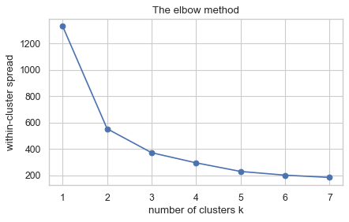

```python
inertia = [KMeans(n_clusters=k, n_init=10, random_state=42).fit(StandardScaler().fit_transform(X)).inertia_ for k in range(1, 8)]
plt.figure(figsize=(6, 3.5))
plt.plot(range(1, 8), inertia, marker="o")
plt.xlabel("number of clusters k")
plt.ylabel("within-cluster spread")
plt.title("The elbow method")
plt.show()
```

**What we see.** If we did not know there were three species, how would we choose *k*? The **elbow method** plots how tightly packed the clusters are against *k*. The spread falls steeply up to about 3 and more slowly after: the "elbow" suggests 2 or 3 groups. The elbow is a hint, not a proof; here it agrees reasonably with biology, but on many datasets it is not clear at all.

## 6. The smallest set of measurements

Now we use the labels, and ask how much each measurement is worth. We train a logistic regression on different sets of measurements and score it with 5-fold cross-validation.

```python
from sklearn.model_selection import StratifiedKFold, cross_val_score
from sklearn.linear_model import LogisticRegression
from sklearn.pipeline import make_pipeline

y = df["species"]
cv = StratifiedKFold(n_splits=5, shuffle=True, random_state=42)
model = make_pipeline(StandardScaler(), LogisticRegression(max_iter=2000))

candidates = {
    "flipper length only": ["flipper_length_mm"],
    "bill length only": ["bill_length_mm"],
    "bill length + flipper length": ["bill_length_mm", "flipper_length_mm"],
    "bill length + bill depth": ["bill_length_mm", "bill_depth_mm"],
    "all four measurements": measures,
}
pd.Series({name: cross_val_score(model, df[cols], y, cv=cv).mean() for name, cols in candidates.items()}, name="accuracy").to_frame()
```

|  | accuracy |
| --- | --- |
| flipper length only | 0.799 |
| bill length only | 0.748 |
| bill length + flipper length | 0.955 |
| bill length + bill depth | 0.958 |
| all four measurements | 0.988 |

**What we see.**

- **One** measurement is not enough: flipper length gives **80%** (it finds Gentoo but mixes the other two), bill length **75%**.
- **Two** well-chosen measurements give about **95%**: bill length with flipper length, or with bill depth.
- All **four** give **99%**.

All far above the 43.8% baseline. For a field researcher, two measurements with a ruler already identify the species almost every time, which is exactly what the pair plot suggested.

```
Cross-validated accuracy of a two-question tree: 0.934
```

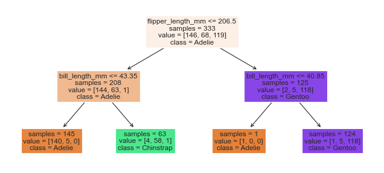

```python
from sklearn.tree import DecisionTreeClassifier, plot_tree

tree = DecisionTreeClassifier(max_depth=2, random_state=42).fit(df[["bill_length_mm", "flipper_length_mm"]], y)
print("Cross-validated accuracy of a two-question tree:",
      round(cross_val_score(DecisionTreeClassifier(max_depth=2, random_state=42), df[["bill_length_mm", "flipper_length_mm"]], y, cv=cv).mean(), 3))
plt.figure(figsize=(10, 4.5))
plot_tree(tree, feature_names=["bill_length_mm", "flipper_length_mm"], class_names=tree.classes_, filled=True, impurity=False)
plt.show()
```

**What we see.** A tree that asks only **two questions** reaches **93%**. Its rules can be written on a card: *if the flipper is longer than about 206 mm, it is a Gentoo (unless the bill is very short); otherwise, a bill longer than about 43 mm means Chinstrap, and a shorter one means Adelie.* A slightly less accurate model that a person can carry in their head is often more useful than a perfect one they cannot.

## 7. Answer to the question

*Can we tell which species a penguin is from its measurements?*

1. **Yes, easily:** four measurements identify the species **99%** of the time, and two well-chosen ones about **95%**.
2. **Each measurement separates different species:** size (flipper, mass) picks out Gentoo, bill length picks out Adelie, so the best pairs combine bill length with a size or shape measurement.
3. **The species are visible without labels:** k-means rediscovers them with an agreement of 0.80, **but only after scaling**; without scaling, the grams drown out the millimetres.
4. **Beware mixed groups:** bill length and depth look negatively related over all penguins and are positively related within every species (Simpson's paradox), and sex differences in mass are larger than some species differences.
5. **Island is not a measurement:** it predicts species almost perfectly, but only because of where each species lives.

## 🚀 Going further (for experienced students)

### A. How sure can we be about the number of clusters?

The elbow is a visual hint. The **silhouette score** measures, for every point, how much closer it is to its own cluster than to the nearest other one: near 1 means well separated, near 0 means on a border.

```python
from sklearn.metrics import silhouette_score

scaled = StandardScaler().fit_transform(X)
silhouette = {k: silhouette_score(scaled, KMeans(n_clusters=k, n_init=10, random_state=42).fit_predict(scaled)) for k in range(2, 7)}
pd.Series(silhouette, name="silhouette").round(3).to_frame().T
```

|  | 2 | 3 | 4 | 5 | 6 |
| --- | --- | --- | --- | --- | --- |
| silhouette | 0.531 | 0.446 | 0.398 | 0.374 | 0.364 |

**What we see.** The silhouette is highest for **k = 2** (**0.53**), then 0.45 for k = 3. On numbers alone, the data says *two* groups (Gentoo and the rest) more clearly than three, because Adelie and Chinstrap overlap in size. Biology says three. A cluster count chosen by a score describes the **geometry** of the data, not necessarily the categories that matter.

### B. Drawing the decision boundaries

A model with two inputs can be drawn: colour every point of the plane by the species the model would predict there.

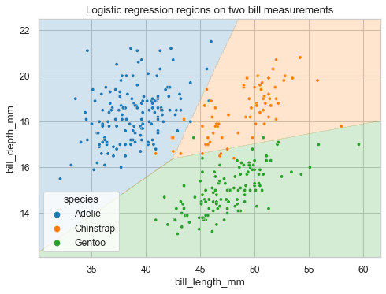

```python
two = ["bill_length_mm", "bill_depth_mm"]
clf = make_pipeline(StandardScaler(), LogisticRegression(max_iter=2000)).fit(df[two], y)
xx, yy = np.meshgrid(np.linspace(df[two[0]].min() - 2, df[two[0]].max() + 2, 300),
                     np.linspace(df[two[1]].min() - 1, df[two[1]].max() + 1, 300))
grid = pd.DataFrame({two[0]: xx.ravel(), two[1]: yy.ravel()})
zone = pd.Series(clf.predict(grid)).map({s: i for i, s in enumerate(clf.classes_)}).values.reshape(xx.shape)
plt.figure(figsize=(7, 5))
plt.contourf(xx, yy, zone, alpha=0.2, levels=[-0.5, 0.5, 1.5, 2.5], colors=["tab:blue", "tab:orange", "tab:green"])
sns.scatterplot(data=df, x=two[0], y=two[1], hue="species", hue_order=list(clf.classes_),
                palette=["tab:blue", "tab:orange", "tab:green"], s=15)
plt.title("Logistic regression regions on two bill measurements")
plt.show()
```

**What we see.** With only bill length and bill depth, three straight-edged regions separate the species well: Adelie top left (short, deep bills), Chinstrap top right (long, deep), Gentoo at the bottom (long, shallow). The few points in the wrong colour region are the birds the model gets wrong, mostly near the Adelie and Chinstrap border. Logistic regression can only draw straight borders; a tree would draw rectangles, and k nearest neighbours irregular shapes.

## ⚠️ Common pitfalls

- **Trusting a pooled correlation when the data contains groups.** The bill correlation changed sign once species was taken into account.
- **Using distances on unscaled data.** k-means, k-nearest neighbours and any method that measures distance will be dominated by the variable with the largest numbers.
- **Letting a "shortcut" variable in.** `island` predicts species, but for the wrong reason; in a new place, it would fail completely.
- **Reading the elbow as a rule.** It suggests a number of clusters; it does not prove one.
- **Ignoring class balance.** With 44% Adelie, an accuracy of 50% would be barely better than always guessing Adelie.

## ✏️ Exercises

### Exercise 1 (Heaviest per island)

Which **island** has the heaviest penguins on average, and is that because of the island or because of the species living there? Use a two-way table.

```python
# Your solution here:
```

**💡 Show solution**

```
print(df.groupby("island")["body_mass_g"].mean().round(0))
print(df.pivot_table(index="species", columns="island", values="body_mass_g").round(0))
```

*Biscoe has by far the heaviest penguins, but only because all the Gentoo live there. The Adelie on Biscoe weigh about the same as the Adelie on the other islands: the island effect is a species effect, the same confounding as the Titanic's port.*

### Exercise 2 (Sex from measurements)

Within **Adelie** penguins only, how well can a logistic regression predict **sex** from the four measurements? Use 5-fold cross-validation and compare with the majority baseline.

```python
# Your solution here:
```

**💡 Show solution**

```
adelie = df[df["species"] == "Adelie"]
score = cross_val_score(model, adelie[measures], adelie["sex"], cv=cv).mean()
print("baseline:", round(adelie["sex"].value_counts(normalize=True).max(), 3), " model:", round(score, 3))
```

*Within one species, males are larger in every measurement, so sex can be predicted well above the 50% baseline. Mixing species would make it much harder, because a large female of one species looks like a small male of another.*

### Exercise 3 (Clusters of two)

Run k-means with **k = 2** on the scaled measurements. Which species end up together? Does this agree with the box plots?

```python
# Your solution here:
```

**💡 Show solution**

```
two = KMeans(n_clusters=2, n_init=10, random_state=42).fit_predict(StandardScaler().fit_transform(X))
print(pd.crosstab(df["species"], two))
```

*With only two groups, k-means separates Gentoo from the rest: Adelie and Chinstrap fall together, because they are about the same size. The biggest difference in the data, size, is the first split any method finds.*

## 🔑 Key takeaways

- **Measurements** are explored with box plots per group, then **pair plots**, looking for panels where groups form separate clouds.
- Different measurements separate different groups; **combinations** succeed where single variables fail.
- **Simpson's paradox:** a trend in the whole dataset can reverse inside every group. Always ask what groups your data contains.
- **Scale your features** before any method based on distance.
- **Clustering** can rediscover real groups without labels, and comparing clusters with known labels tells you how real they are.
- Keep out variables that predict the answer for the **wrong reason**, such as where the data was collected.

**Next:** *Notebook 03: House Prices*, where the answer is a number instead of a category, and the data has 80 columns, many of them missing.

*© Ioannis Tsioulis. *From Questions to Answers: Classic Datasets, Fully Explored*. Prepared for educational use.*